# SE case study

xidan chen

08-April-2019 CEST

# 1. Objective

The dataset contains several different interaction types per deal (product) along with the number of unique participants and deal properties.

Develop an algorithm to optimize for the conversion rate. Your algorithm should provide a ranking of all deals regardless of whether or not an actual order occurred.

**note: given what we have here, we are interested in what deal property information is useful in order to build recommendations that would maximize the conversion rate.**

# 2. Importing necessary packages

```r
#for data manipulation and tidying
library(dplyr)
library(mice)
#library(naniar)

#for data visualization
library(ggplot2)
library(GGally)



#for analysis
#library(psych)
#library(pscl)
library(MASS)
```

# 3. Importing data

```r
data <- read.csv("dataset_case_data_science_2019.csv", header = TRUE, sep = ",")
```

# 4. Data preparation

Some notes about specific dataset fields:  
● Sale_id: unique deal identifier —should be DEAL_ID  
● Deal Start: deal activation date  
● Deal End: deal deactivation date  
● Has_tag_ - human added labels, where values are yes (=1) or no (=0) and indicate if the label is present or not  
● Show_price: yes (=1) or no (=0)  
● Unique_visitors_bookings: how many visitors booked a deal  
● Unique_visitors_deal_pageview: how many visitors interacted with deal’s page  
● Unique_visitors_book_form: how many visitors interacted with deal’s booking for

conversion rate, defined as the number of bookings (field: unique_visitors_bookings) divided by the number of unique pageview visitors (field: unique_visitors_deal_pageview)

conversion = UNIQUE_VISITORS_BOOKINGS/UNIQUE_VISITORS_DEAL_PAGEVIEW

## data structure

```r
head(data, 10)
```

|  | UNIQUE_VISITORS_DEAL_PAGEVIEW | UNIQUE_VISITORS_BOOK_FORM | UNIQUE_VISITORS_BOOKINGS | DEAL_ID | DEAL_START | DEAL_END | SLUG | TITLE | ROOM_DESCRIPTION | DESTINATION_NAME | SHOW_PRICE | BOARD_TYPE | DESTINATION_TYPE | TRAVEL_TYPE | TOP_DISCOUNT_GBP | HAS_TAG_FOOD | HAS_TAG_RELAXING | HAS_TAG_SCENERY | HAS_TAG_FLIGHTS | HAS_TAG_SIGHTSEEING | HAS_TAG_BEACH | HAS_TAG_ROMANCE | HAS_TAG_EUROPE | HAS_TAG_UKANDIRELAND | HAS_TAG_BOUTIQUE | HAS_TAG_SHOPPING | HAS_TAG_HISTORICHOTEL | HAS_TAG_COUNTRY | HAS_TAG_ACTIVITIES | … |
| --- | --- | --- | --- | --- | --- | --- | --- | --- | --- | --- | --- | --- | --- | --- | --- | --- | --- | --- | --- | --- | --- | --- | --- | --- | --- | --- | --- | --- | --- | --- |
| 1 | 29133 | 2105 | 30 | 85342 | 2019-01-04 00:01:00 | 2019-01-28 23:59:00 | Escape to balmy Barbados with an all-inclusive stay in St. Lawrence Gap, set along a pristine white-sand beach - includes oceanfront room upgrade and all travel | All-inclusive Barbados holiday with oceanfront room upgrade | suite | Barbados Beach Club Resort, Caribbean | true | ALL_INCLUSIVE | LONG_HAUL | FLIGHT | 50 | 0 | 1 | 0 | 0 | 0 | 0 | 0 | 0 | 0 | 0 | 0 | 0 | 0 | 0 | … |
| 2 | 4408 | 367 | 4 | 85982 | 2019-01-11 00:01:00 | 2019-01-21 23:59:00 | A luxuriously modern stay at Hotel Olympia's sleek, recently-opened wing, right on the Croatian coast â\200“ including half board and all travel | Blissful Croatia beach holiday | room | Hotel Olympia Sky, Vodice | true | BED_N_BREAKFAST | EUROPE | FLIGHT | 24 | 0 | 0 | 0 | 0 | 0 | 0 | 0 | 0 | 0 | 0 | 0 | 0 | 0 | 0 | … |
| 3 | 7910 | 955 | 19 | 88889 | 2019-02-18 00:01:00 | 2019-03-11 23:59:00 | A glitzy, five-star stay on the shores of Dubai's Jumeirah Beach, including breakfast, dinner, and access to the Polo lounge with drinks | Habtoor Grand Resort, Autograph Collection | room | Dubai, UAE | true | BED_N_BREAKFAST | MIDDLE_HAUL | FLIGHT | 65 | 0 | 0 | 0 | 0 | 0 | 0 | 0 | 0 | 0 | 0 | 0 | 0 | 0 | 0 | … |
| 4 | 11029 | 224 | 22 | 89324 | 2019-02-23 12:00:00 | 2019-03-08 23:59:00 | A sophisticated Tuscany break with tickets to see Andrea Bocelli sing in his hometown, plus cultural and foodie outings â\200“ includes breakfast and all travel | Dreamy Tuscany foodie break with an Andrea Bocelli concert & cultural city tours | room | Hotel Arnolfo & Aqua Laetitia Spa & Beauty, Italy | true | BED_N_BREAKFAST | EUROPE | FLIGHT | 33 | 0 | 0 | 0 | 0 | 1 | 0 | 0 | 0 | 0 | 0 | 0 | 0 | 0 | 0 | … |
| 5 | 3164 | 74 | 0 | 86999 | 2019-01-25 00:01:00 | 2019-02-04 23:59:00 | An all-inclusive holiday at a modern beachfront resort on Turkeyâ\200\231s Mediterranean coast, outside the ancient city of Side â\200“ includes all travel | 5* all-inclusive Turkey beach getaway with optional swim-up pool | room | Barut Hemera, Antalya | true | ALL_INCLUSIVE | EUROPE | FLIGHT | 0 | 0 | 0 | 0 | 0 | 0 | 0 | 0 | 0 | 0 | 0 | 0 | 0 | 0 | 0 | … |
| 6 | 5343 | 298 | 12 | 85201 | 2019-01-18 00:01:00 | 2019-01-28 23:59:00 | An ultra all-inclusive beach holiday in Hurghada, staying at an award-winning Red Sea resort with a spa and modern-meets-traditional interiors - all travel included | Ultra all-inclusive Red Sea getaway to an award-winning beach hotel | room | Old Palace Resort, Egypt | true | ALL_INCLUSIVE | MIDDLE_HAUL | FLIGHT | 33 | 0 | 0 | 0 | 0 | 0 | 0 | 0 | 0 | 0 | 0 | 0 | 0 | 0 | 0 | … |
| 7 | 1864 | 45 | 18 | 84646 | 2018-12-17 00:01:00 | 2019-01-02 23:59:00 | A romantic English country manor stay in Stourport-on-Severn, including breakfast, dinner options and prosecco | Hallmark Hotel Stourport Manor | room | Stourport-on-Severn, Worcestershire | true | HALF_BOARD | UK | FLIGHT | 0 | 0 | 0 | 0 | 0 | 1 | 0 | 0 | 0 | 0 | 0 | 0 | 0 | 0 | 0 | … |
| 8 | 3709 | 238 | 11 | 88881 | 2019-02-17 00:01:00 | 2019-03-04 23:59:00 | An elegant 19th-century Tuscan hotel with thermal pools and a natural cave â\200“ includes breakfast, optional dinner, plus spa and dining discounts | Grotta Giusti | room | Tuscany, Italy | true | BED_N_BREAKFAST | EUROPE | FLIGHT | 40 | 0 | 0 | 0 | 0 | 0 | 0 | 0 | 0 | 0 | 0 | 0 | 0 | 0 | 0 | … |
| 9 | 12227 | 378 | 84 | 85512 | 2019-01-07 00:01:00 | 2019-02-12 23:59:00 | An award-winning Welsh country house hotel with a spa set in 50 acres of scenic grounds in Powys â\200“ includes breakfast and optional three-course dinner with suite stay | Lake Country House Hotel & Spa | room | Powys, Wales | true | BED_N_BREAKFAST | UK | FLIGHT | 0 | 0 | 0 | 0 | 0 | 0 | 0 | 0 | 0 | 0 | 0 | 0 | 0 | 1 | 0 | … |
| 10 | 1932 | 51 | 1 | 84317 | 2018-12-08 16:00:00 | 2018-12-10 10:00:00 | An Egypt escape combining a bucket-list Nile cruise, taking in incredible sights, with a five-star, all-inclusive beach resort â\200“ includes travel | 5* all-inclusive Egypt beach holiday with a Nile river cruise | room | MS Al Jamila, River Nile & Hilton Hurghada Resort | true | FULL_BOARD | MIDDLE_HAUL | FLIGHT | 23 | 1 | 0 | 0 | 0 | 0 | 0 | 0 | 0 | 0 | 0 | 0 | 0 | 0 | 0 | … |

```r
names(data)
```

```
##  [1] "UNIQUE_VISITORS_DEAL_PAGEVIEW" "UNIQUE_VISITORS_BOOK_FORM"
##  [3] "UNIQUE_VISITORS_BOOKINGS"      "DEAL_ID"
##  [5] "DEAL_START"                    "DEAL_END"
##  [7] "SLUG"                          "TITLE"
##  [9] "ROOM_DESCRIPTION"              "DESTINATION_NAME"
## [11] "SHOW_PRICE"                    "BOARD_TYPE"
## [13] "DESTINATION_TYPE"              "TRAVEL_TYPE"
## [15] "TOP_DISCOUNT_GBP"              "HAS_TAG_FOOD"
## [17] "HAS_TAG_RELAXING"              "HAS_TAG_SCENERY"
## [19] "HAS_TAG_FLIGHTS"               "HAS_TAG_SIGHTSEEING"
## [21] "HAS_TAG_BEACH"                 "HAS_TAG_ROMANCE"
## [23] "HAS_TAG_EUROPE"                "HAS_TAG_UKANDIRELAND"
## [25] "HAS_TAG_BOUTIQUE"              "HAS_TAG_SHOPPING"
## [27] "HAS_TAG_HISTORICHOTEL"         "HAS_TAG_COUNTRY"
## [29] "HAS_TAG_ACTIVITIES"            "HAS_TAG_DRINK"
## [31] "HAS_TAG_HOTEL"                 "HAS_TAG_MODERNINTERIOR"
## [33] "HAS_TAG_MULTIDEST"             "HAS_TAG_ALLINCLUSIVE"
## [35] "HAS_TAG_LONGHAUL"              "HAS_TAG_SHORTHAUL"
## [37] "HAS_TAG_ENTERTAINMENT"
```

```r
str(data)
```

```
## 'data.frame':    7356 obs. of  37 variables:
##  $ UNIQUE_VISITORS_DEAL_PAGEVIEW: int  29133 4408 7910 11029 3164 5343 1864 3709 12227 1932 ...
##  $ UNIQUE_VISITORS_BOOK_FORM    : int  2105 367 955 224 74 298 45 238 378 51 ...
##  $ UNIQUE_VISITORS_BOOKINGS     : int  30 4 19 22 0 12 18 11 84 1 ...
##  $ DEAL_ID                      : int  85342 85982 88889 89324 86999 85201 84646 88881 85512 84317 ...
##  $ DEAL_START                   : Factor w/ 644 levels "2018-01-01 00:01:00",..: 548 558 615 622 581 569 523 613 553 510 ...
##  $ DEAL_END                     : Factor w/ 595 levels "2017-12-10 23:59:00",..: 524 514 581 579 537 524 487 574 549 456 ...
##  $ SLUG                         : Factor w/ 6478 levels "","16th century Norfolk manor house stay with its own golf course and award-winning restaurant, including breakfast",..: 5242 1928 1453 3005 3838 4467 2646 4027 3973 4015 ...
##  $ TITLE                        : Factor w/ 5934 levels "1 Hotel Brooklyn Bridge",..: 687 1151 2607 2003 121 5728 2619 2552 3366 69 ...
##  $ ROOM_DESCRIPTION             : Factor w/ 24 levels "apartment","bedroom",..: 16 12 12 12 12 12 12 12 12 12 ...
##  $ DESTINATION_NAME             : Factor w/ 4079 levels "","3 Nagas Luang Prabang - MGallery by Sofitel, Laos",..: 328 1752 1034 1584 344 2741 3501 3820 2927 2581 ...
##  $ SHOW_PRICE                   : Factor w/ 2 levels "false","true": 2 2 2 2 2 2 2 2 2 2 ...
##  $ BOARD_TYPE                   : Factor w/ 5 levels "ALL_INCLUSIVE",..: 1 2 2 2 1 1 4 2 2 3 ...
##  $ DESTINATION_TYPE             : Factor w/ 5 levels "EUROPE","LONDON",..: 3 1 4 1 1 4 5 1 5 4 ...
##  $ TRAVEL_TYPE                  : Factor w/ 2 levels "FLIGHT","TRAIN": 1 1 1 1 1 1 1 1 1 1 ...
```

[output cut: 23 more lines]

```r
#summary(data)
```

## preprocessing: check duplicate, missingness, consistency

1. convert variables start with HAS_TAG_X to factors
2. no duplicated data was identified
3. data is complete
4. 7 deals were identified and removed as their deal end time is earlier or equal to the deal start time. These deals’ ID are:(86064 84573 65765 89630 86385 88374 84049)
5. books and pageview data are consistent
6. other categorical data/qualitative data were not checked. Given currently available data, there is no way to cross-validate these data.
7. conversion rate is highly skewed, would need further treatment
8. reduce categories of variables ROOM_DESCRIPTION
9. I am not sure if I can drop redundant informations in has_tag_x variables. For example, HAS_TAG_EUROPE, and DESTINATION_TYPE both include the information europe for the deal. on the other hand has_tag_x could be features on the webpage, not necessariely have to be the deal character. I thus check the counts for both variables and found counts for europe are different which favors the second idea, has_tag_x are features on the webpage. therefore all the has_tag_variables are kept at the preprocessing step.

```r
#convert variables start with HAS_TAG_X to factors
data <- data %>%
  mutate_at(vars(starts_with("HAS_TAG_")), funs(factor))


#check duplicate
data[duplicated(data)]
```

```r
#check missing pattern
md.pattern(data)
```

```
##  /\     /\
## {  `---'  }
## {  O   O  }
## ==>  V <==  No need for mice. This data set is completely observed.
##  \  \|/  /
##   `-----'
```

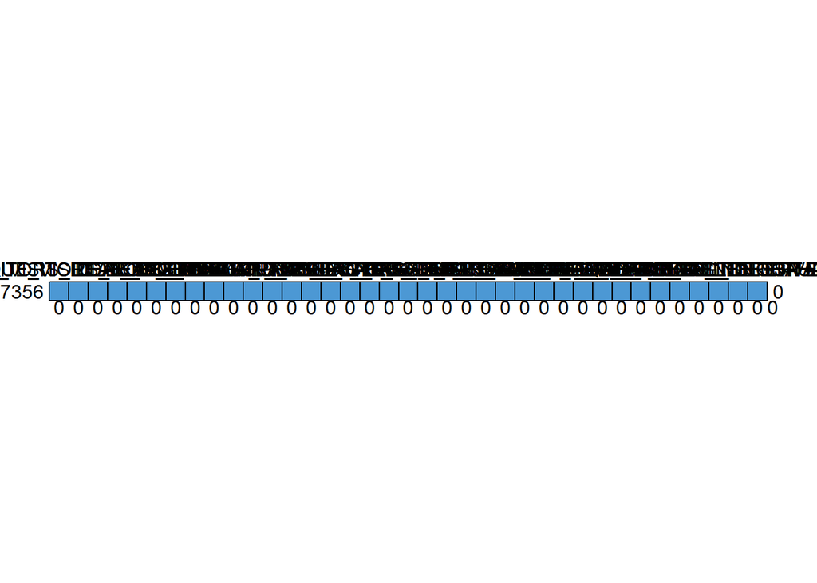

```
##      UNIQUE_VISITORS_DEAL_PAGEVIEW UNIQUE_VISITORS_BOOK_FORM
## 7356                             1                         1
##                                  0                         0
##      UNIQUE_VISITORS_BOOKINGS DEAL_ID DEAL_START DEAL_END SLUG TITLE
## 7356                        1       1          1        1    1     1
##                             0       0          0        0    0     0
##      ROOM_DESCRIPTION DESTINATION_NAME SHOW_PRICE BOARD_TYPE
## 7356                1                1          1          1
##                     0                0          0          0
##      DESTINATION_TYPE TRAVEL_TYPE TOP_DISCOUNT_GBP HAS_TAG_FOOD
## 7356                1           1                1            1
##                     0           0                0            0
##      HAS_TAG_RELAXING HAS_TAG_SCENERY HAS_TAG_FLIGHTS HAS_TAG_SIGHTSEEING
## 7356                1               1               1                   1
##                     0               0               0                   0
##      HAS_TAG_BEACH HAS_TAG_ROMANCE HAS_TAG_EUROPE HAS_TAG_UKANDIRELAND
## 7356             1               1              1                    1
##                  0               0              0                    0
##      HAS_TAG_BOUTIQUE HAS_TAG_SHOPPING HAS_TAG_HISTORICHOTEL
## 7356                1                1                     1
##                     0                0                     0
##      HAS_TAG_COUNTRY HAS_TAG_ACTIVITIES HAS_TAG_DRINK HAS_TAG_HOTEL
## 7356               1                  1             1             1
##                    0                  0             0             0
##      HAS_TAG_MODERNINTERIOR HAS_TAG_MULTIDEST HAS_TAG_ALLINCLUSIVE
## 7356                      1                 1                    1
##                           0                 0                    0
##      HAS_TAG_LONGHAUL HAS_TAG_SHORTHAUL HAS_TAG_ENTERTAINMENT
## 7356                1                 1                     1 0
##                     0                 0                     0 0
```

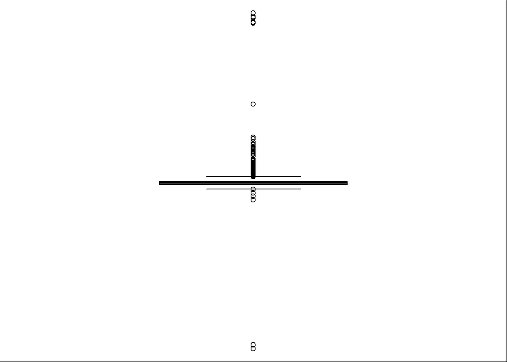

```r
#check if time stamps are correct. time difference should be larger than 0 if time stamps are correct.
data <- data %>%
  mutate(deal_time = as.numeric(difftime(DEAL_END, DEAL_START)))


boxplot(data$deal_time)
```

```r
summary(data$deal_time)
```

```
##      Min.   1st Qu.    Median      Mean   3rd Qu.      Max.
## -30844920    950280   1295880   1340677   1555080  34127880
```

```r
data[data$deal_time <= 0, ]$DEAL_ID #get deal ID for those having incorrect time stamps
```

```
## [1] 86064 84573 65765 89630 86385 88374 84049
```

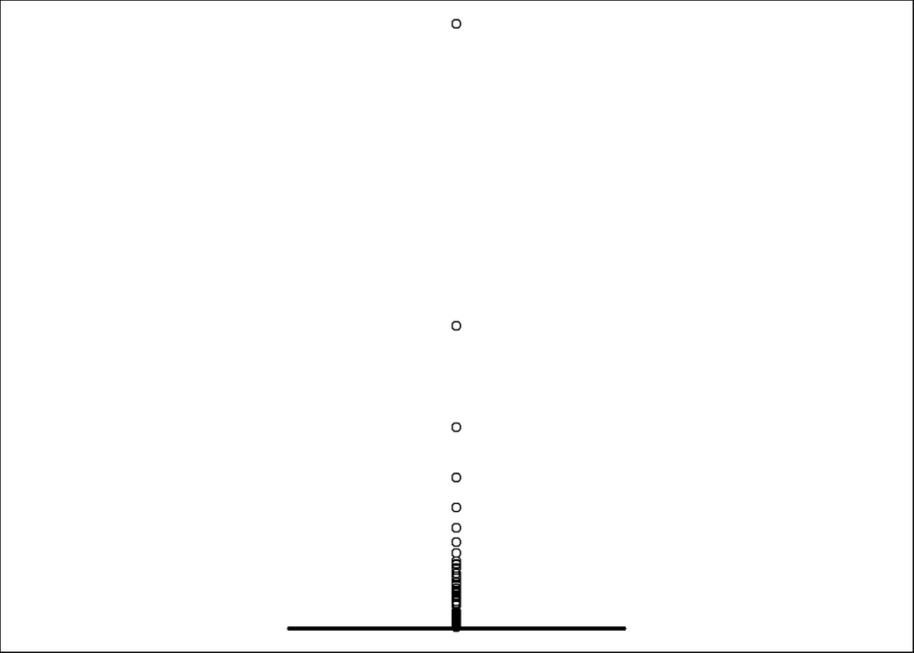

```r
#remove 7 deals
data <- data %>%
  filter(deal_time > 0)


#check if bookings is less than pageview. conversion rate should be between 0 and 1.
data <- data %>%
  mutate(conversion = UNIQUE_VISITORS_BOOKINGS/UNIQUE_VISITORS_DEAL_PAGEVIEW)

boxplot(data$conversion)
```

```r
summary(data$conversion)
```

```
##      Min.   1st Qu.    Median      Mean   3rd Qu.      Max.
## 0.0000000 0.0000000 0.0000000 0.0029422 0.0008734 1.0000000
```

```r
#hist(data$conversion)

#recode room_description into categories: rooms, suite, others
#? is zimmer = rooms???
table(data$ROOM_DESCRIPTION)
```

```
##
##       apartment         bedroom        bungalow           cabin
##             112               3              31              35
##         cottage           house           igloo           lodge
##              21               1               3              18
##            loft       penthouse       residence            room
##               2               1               1            6335
##           rooms            stay          studio           suite
##               3              11              54             473
##           Suite            tent            unit           villa
##               1               2              10             225
## villa/apartment         voucher            yurt          Zimmer
##               1               1               4               1
```

```r
#what is villa/apartment?
lst <- c(room = "rooms", rooms = "rooms", Zimmer = "rooms",
                                suite = "suite", Suite = "suite",
                                villa = "villa/apartment",
                                apartment = "villa/apartment"
                             #  villa/apartment = "villa/apartment"
                            #    .default = "others"
         )

#tst <- data

#tst$ROOM_DESCRIPTION <- recode(tst$ROOM_DESCRIPTION, !!!lst, .default = "others")
#table(tst$ROOM_DESCRIPTION)
data$ROOM_DESCRIPTION <- recode(data$ROOM_DESCRIPTION, !!!lst, .default = "others")
#recode BOARD_TYPE?
#table(data$BOARD_TYPE)

#recode DESTINATION_TYPE?
#table(data$DESTINATION_TYPE)
#table(data$HAS_TAG_EUROPE)

data2 <- data
```

## select relevant variables

“SLUG”, “TITLE”, “DESTINATION_NAME” are redundant information, thus not included in analysis. drop “UNIQUE_VISITORS_DEAL_PAGEVIEW”, “UNIQUE_VISITORS_BOOK_FORM”, “UNIQUE_VISITORS_BOOKINGS”, “DEAL_START”, “DEAL_END” information have been included in variables - conversion and deal_time

come across errors in the final run with original syntax

```r
# sub1 <- data %>%
#   select_at(-c(SLUG, TITLE, DESTINATION_NAME, UNIQUE_VISITORS_DEAL_PAGEVIEW, UNIQUE_VISITORS_BOOK_FORM, UNIQUE_VISITORS_BOOKINGS, DEAL_START, DEAL_END))

# lst2 <- c("SLUG", "TITLE", "DESTINATION_NAME","UNIQUE_VISITORS_DEAL_PAGEVIEW", "UNIQUE_VISITORS_BOOK_FORM", "UNIQUE_VISITORS_BOOKINGS", "DEAL_START", "DEAL_END")

 sub1 <- data2[, -c(1:3, 5:8)]

names(data2)
```

```
##  [1] "UNIQUE_VISITORS_DEAL_PAGEVIEW" "UNIQUE_VISITORS_BOOK_FORM"
##  [3] "UNIQUE_VISITORS_BOOKINGS"      "DEAL_ID"
##  [5] "DEAL_START"                    "DEAL_END"
##  [7] "SLUG"                          "TITLE"
##  [9] "ROOM_DESCRIPTION"              "DESTINATION_NAME"
## [11] "SHOW_PRICE"                    "BOARD_TYPE"
## [13] "DESTINATION_TYPE"              "TRAVEL_TYPE"
## [15] "TOP_DISCOUNT_GBP"              "HAS_TAG_FOOD"
## [17] "HAS_TAG_RELAXING"              "HAS_TAG_SCENERY"
## [19] "HAS_TAG_FLIGHTS"               "HAS_TAG_SIGHTSEEING"
## [21] "HAS_TAG_BEACH"                 "HAS_TAG_ROMANCE"
## [23] "HAS_TAG_EUROPE"                "HAS_TAG_UKANDIRELAND"
## [25] "HAS_TAG_BOUTIQUE"              "HAS_TAG_SHOPPING"
## [27] "HAS_TAG_HISTORICHOTEL"         "HAS_TAG_COUNTRY"
## [29] "HAS_TAG_ACTIVITIES"            "HAS_TAG_DRINK"
## [31] "HAS_TAG_HOTEL"                 "HAS_TAG_MODERNINTERIOR"
## [33] "HAS_TAG_MULTIDEST"             "HAS_TAG_ALLINCLUSIVE"
## [35] "HAS_TAG_LONGHAUL"              "HAS_TAG_SHORTHAUL"
## [37] "HAS_TAG_ENTERTAINMENT"         "deal_time"
## [39] "conversion"
```

```r
#levels(sub1$ROOM_DESCRIPTION)

names(sub1)
```

```
##  [1] "DEAL_ID"                "ROOM_DESCRIPTION"
##  [3] "DESTINATION_NAME"       "SHOW_PRICE"
##  [5] "BOARD_TYPE"             "DESTINATION_TYPE"
##  [7] "TRAVEL_TYPE"            "TOP_DISCOUNT_GBP"
##  [9] "HAS_TAG_FOOD"           "HAS_TAG_RELAXING"
## [11] "HAS_TAG_SCENERY"        "HAS_TAG_FLIGHTS"
## [13] "HAS_TAG_SIGHTSEEING"    "HAS_TAG_BEACH"
## [15] "HAS_TAG_ROMANCE"        "HAS_TAG_EUROPE"
## [17] "HAS_TAG_UKANDIRELAND"   "HAS_TAG_BOUTIQUE"
## [19] "HAS_TAG_SHOPPING"       "HAS_TAG_HISTORICHOTEL"
## [21] "HAS_TAG_COUNTRY"        "HAS_TAG_ACTIVITIES"
## [23] "HAS_TAG_DRINK"          "HAS_TAG_HOTEL"
## [25] "HAS_TAG_MODERNINTERIOR" "HAS_TAG_MULTIDEST"
## [27] "HAS_TAG_ALLINCLUSIVE"   "HAS_TAG_LONGHAUL"
## [29] "HAS_TAG_SHORTHAUL"      "HAS_TAG_ENTERTAINMENT"
## [31] "deal_time"              "conversion"
```

```r
head(sub1)
```

|  | DEAL_ID | ROOM_DESCRIPTION | DESTINATION_NAME | SHOW_PRICE | BOARD_TYPE | DESTINATION_TYPE | TRAVEL_TYPE | TOP_DISCOUNT_GBP | HAS_TAG_FOOD | HAS_TAG_RELAXING | HAS_TAG_SCENERY | HAS_TAG_FLIGHTS | HAS_TAG_SIGHTSEEING | HAS_TAG_BEACH | HAS_TAG_ROMANCE | HAS_TAG_EUROPE | HAS_TAG_UKANDIRELAND | HAS_TAG_BOUTIQUE | HAS_TAG_SHOPPING | HAS_TAG_HISTORICHOTEL | HAS_TAG_COUNTRY | HAS_TAG_ACTIVITIES | HAS_TAG_DRINK | HAS_TAG_HOTEL | HAS_TAG_MODERNINTERIOR | HAS_TAG_MULTIDEST | HAS_TAG_ALLINCLUSIVE | HAS_TAG_LONGHAUL | HAS_TAG_SHORTHAUL | … |
| --- | --- | --- | --- | --- | --- | --- | --- | --- | --- | --- | --- | --- | --- | --- | --- | --- | --- | --- | --- | --- | --- | --- | --- | --- | --- | --- | --- | --- | --- | --- |
| 1 | 85342 | suite | Barbados Beach Club Resort, Caribbean | true | ALL_INCLUSIVE | LONG_HAUL | FLIGHT | 50 | 0 | 1 | 0 | 0 | 0 | 0 | 0 | 0 | 0 | 0 | 0 | 0 | 0 | 0 | 0 | 0 | 0 | 0 | 0 | 0 | 0 | … |
| 2 | 85982 | rooms | Hotel Olympia Sky, Vodice | true | BED_N_BREAKFAST | EUROPE | FLIGHT | 24 | 0 | 0 | 0 | 0 | 0 | 0 | 0 | 0 | 0 | 0 | 0 | 0 | 0 | 0 | 0 | 1 | 0 | 0 | 0 | 0 | 0 | … |
| 3 | 88889 | rooms | Dubai, UAE | true | BED_N_BREAKFAST | MIDDLE_HAUL | FLIGHT | 65 | 0 | 0 | 0 | 0 | 0 | 0 | 0 | 0 | 0 | 0 | 0 | 0 | 0 | 0 | 0 | 0 | 0 | 0 | 0 | 0 | 0 | … |
| 4 | 89324 | rooms | Hotel Arnolfo & Aqua Laetitia Spa & Beauty, Italy | true | BED_N_BREAKFAST | EUROPE | FLIGHT | 33 | 0 | 0 | 0 | 0 | 1 | 0 | 0 | 0 | 0 | 0 | 0 | 0 | 0 | 0 | 0 | 0 | 0 | 0 | 0 | 0 | 0 | … |
| 5 | 86999 | rooms | Barut Hemera, Antalya | true | ALL_INCLUSIVE | EUROPE | FLIGHT | 0 | 0 | 0 | 0 | 0 | 0 | 0 | 0 | 0 | 0 | 0 | 0 | 0 | 0 | 0 | 0 | 0 | 0 | 0 | 0 | 0 | 0 | … |
| 6 | 85201 | rooms | Old Palace Resort, Egypt | true | ALL_INCLUSIVE | MIDDLE_HAUL | FLIGHT | 33 | 0 | 0 | 0 | 0 | 0 | 0 | 0 | 0 | 0 | 0 | 0 | 0 | 0 | 0 | 0 | 0 | 0 | 0 | 0 | 0 | 0 | … |

```r
str(sub1)
```

```
## 'data.frame':    7349 obs. of  32 variables:
##  $ DEAL_ID               : int  85342 85982 88889 89324 86999 85201 84646 88881 85512 84317 ...
##  $ ROOM_DESCRIPTION      : Factor w/ 4 levels "villa/apartment",..: 4 3 3 3 3 3 3 3 3 3 ...
##  $ DESTINATION_NAME      : Factor w/ 4079 levels "","3 Nagas Luang Prabang - MGallery by Sofitel, Laos",..: 328 1752 1034 1584 344 2741 3501 3820 2927 2581 ...
##  $ SHOW_PRICE            : Factor w/ 2 levels "false","true": 2 2 2 2 2 2 2 2 2 2 ...
##  $ BOARD_TYPE            : Factor w/ 5 levels "ALL_INCLUSIVE",..: 1 2 2 2 1 1 4 2 2 3 ...
##  $ DESTINATION_TYPE      : Factor w/ 5 levels "EUROPE","LONDON",..: 3 1 4 1 1 4 5 1 5 4 ...
##  $ TRAVEL_TYPE           : Factor w/ 2 levels "FLIGHT","TRAIN": 1 1 1 1 1 1 1 1 1 1 ...
##  $ TOP_DISCOUNT_GBP      : int  50 24 65 33 0 33 0 40 0 23 ...
##  $ HAS_TAG_FOOD          : Factor w/ 2 levels "0","1": 1 1 1 1 1 1 1 1 1 2 ...
##  $ HAS_TAG_RELAXING      : Factor w/ 2 levels "0","1": 2 1 1 1 1 1 1 1 1 1 ...
##  $ HAS_TAG_SCENERY       : Factor w/ 2 levels "0","1": 1 1 1 1 1 1 1 1 1 1 ...
##  $ HAS_TAG_FLIGHTS       : Factor w/ 2 levels "0","1": 1 1 1 1 1 1 1 1 1 1 ...
##  $ HAS_TAG_SIGHTSEEING   : Factor w/ 2 levels "0","1": 1 1 1 2 1 1 2 1 1 1 ...
##  $ HAS_TAG_BEACH         : Factor w/ 2 levels "0","1": 1 1 1 1 1 1 1 1 1 1 ...
```

[output cut: 18 more lines]

# 5. Exploratory

explore relationship between deal properties and conversion rate. the conversion rate is continuous data, I am therefore interested if there are mean-level differences for each deal property.

## tentative visualization

```r
str(sub1)

#ROOM_DESCRIPTION vs. conversion
#24 levels
#'room' having the highest conversion rate
#boxplot(conversion ~ ROOM_DESCRIPTION, sub1)
ggplot(sub1, aes(x=ROOM_DESCRIPTION, y=conversion)) + geom_point() +
  stat_summary(aes(y = conversion,group=1), fun.y=mean, colour="red", geom="line",group=1)

#SHOW_PRICE
#boxplot(conversion ~ SHOW_PRICE, sub1)
ggplot(sub1, aes(x=SHOW_PRICE, y=conversion)) + geom_point() +
  stat_summary(aes(y = conversion,group=1), fun.y=mean, colour="red", geom="line",group=1)


#BOARD_TYPE
boxplot(conversion ~ BOARD_TYPE, sub1)

#DESTINATION_TYPE
boxplot(conversion ~ DESTINATION_TYPE, sub1)

#TRAVEL_TYPE
boxplot(conversion ~ TRAVEL_TYPE, sub1)

#TOP_DISCOUNT_GBP
boxplot(conversion ~ TOP_DISCOUNT_GBP, sub1)

#HAS_TAG_FOOD
boxplot(conversion ~ HAS_TAG_FOOD, sub1)

#HAS_TAG_RELAXING
boxplot(conversion ~ HAS_TAG_RELAXING, sub1)
```

[output not shown]

# 6. Split the data into training and test sets

split data into train (80%) and test (20%)

```r
set.seed(123)
train <- sub1 %>% sample_frac(.80)
test <- anti_join(sub1, train, by = 'DEAL_ID')
```

# 7. Modeling

## how to treat conversion rate?

as shown below, conversion rate data have excessive zeros and overdispersed. two possible approaches for the conversion data: 1). zero-inflated regression models 2). dichotomize/binning the conversion rate to two categories 0 and 1, then apply classification methods.

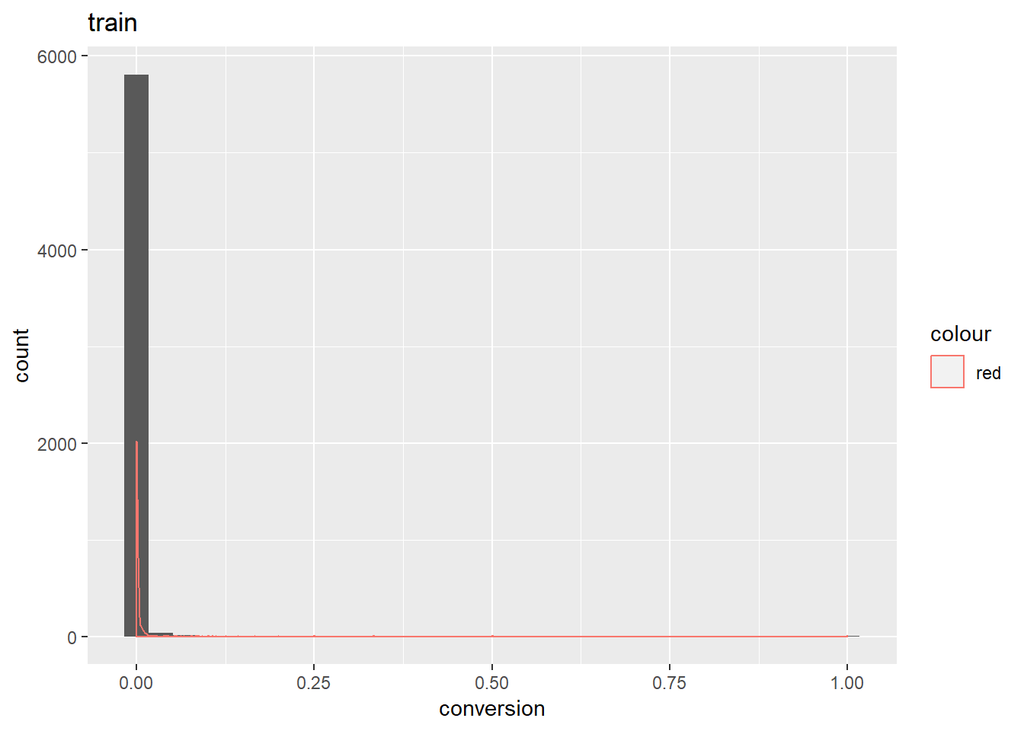

```r
ggplot(train, aes(conversion)) + geom_histogram() + geom_density(aes(colour='red')) + ggtitle('train')
```

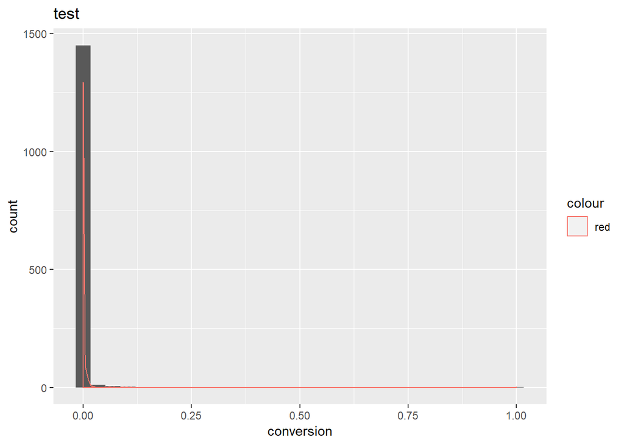

```r
ggplot(test, aes(conversion)) + geom_histogram() + geom_density(aes(colour='red')) + ggtitle('test')
```

## Logistic regression

after the preprocessin, we now have 29 predictors, among which 2 deal_time, top_discount are continuous, others are categorical. perhaps consider feature selection methods?

### data preparation

```r
#recode conversion rate
train <- train %>%
  mutate(conversion_c = ifelse(conversion == 0, 0, 1))
#head(train)
#table(train$conversion_c)

test <- test %>%
  mutate(conversion_c = ifelse(conversion == 0, 0, 1))
```

```r
# standardize deal_time
train$deal_time.scale <- scale(train$deal_time)
test$deal_time.scale <- scale(test$deal_time)
sub1$deal_time.scale <- scale(sub1$deal_time)
#names(train)
```

### model1

**predictor:**  
“ROOM_DESCRIPTION” “SHOW_PRICE” “BOARD_TYPE”  
“DESTINATION_TYPE” “TRAVEL_TYPE” “TOP_DISCOUNT_GBP” “HAS_TAG_FOOD”  
“HAS_TAG_RELAXING” “HAS_TAG_SCENERY” “HAS_TAG_FLIGHTS” “HAS_TAG_SIGHTSEEING”  
“HAS_TAG_BEACH” “HAS_TAG_ROMANCE” “HAS_TAG_EUROPE” “HAS_TAG_UKANDIRELAND”  
“HAS_TAG_BOUTIQUE” “HAS_TAG_SHOPPING” “HAS_TAG_HISTORICHOTEL” “HAS_TAG_COUNTRY” “HAS_TAG_ACTIVITIES” “HAS_TAG_DRINK” “HAS_TAG_HOTEL” “HAS_TAG_MODERNINTERIOR” “HAS_TAG_MULTIDEST” “HAS_TAG_ALLINCLUSIVE” “HAS_TAG_LONGHAUL” “HAS_TAG_SHORTHAUL”  
“HAS_TAG_ENTERTAINMENT” “deal_time.scale” **outcome:** “conversion_c”

```r
glm.fits <- glm(conversion_c ~ ROOM_DESCRIPTION +
SHOW_PRICE +
BOARD_TYPE+
DESTINATION_TYPE+
TRAVEL_TYPE+
TOP_DISCOUNT_GBP+
HAS_TAG_FOOD+
HAS_TAG_RELAXING+
HAS_TAG_SCENERY+
HAS_TAG_FLIGHTS+
HAS_TAG_SIGHTSEEING+
HAS_TAG_BEACH+
HAS_TAG_ROMANCE+
HAS_TAG_EUROPE+
HAS_TAG_UKANDIRELAND+
HAS_TAG_BOUTIQUE+
HAS_TAG_SHOPPING+
HAS_TAG_HISTORICHOTEL+
HAS_TAG_COUNTRY+
HAS_TAG_ACTIVITIES+
HAS_TAG_DRINK+
HAS_TAG_HOTEL+
HAS_TAG_MODERNINTERIOR+
HAS_TAG_MULTIDEST+
HAS_TAG_ALLINCLUSIVE+
HAS_TAG_LONGHAUL+
HAS_TAG_SHORTHAUL+
HAS_TAG_ENTERTAINMENT+
deal_time.scale,
                data = train ,family = binomial)

summary(glm.fits)
```

```
##
## Call:
## glm(formula = conversion_c ~ ROOM_DESCRIPTION + SHOW_PRICE +
##     BOARD_TYPE + DESTINATION_TYPE + TRAVEL_TYPE + TOP_DISCOUNT_GBP +
##     HAS_TAG_FOOD + HAS_TAG_RELAXING + HAS_TAG_SCENERY + HAS_TAG_FLIGHTS +
##     HAS_TAG_SIGHTSEEING + HAS_TAG_BEACH + HAS_TAG_ROMANCE + HAS_TAG_EUROPE +
##     HAS_TAG_UKANDIRELAND + HAS_TAG_BOUTIQUE + HAS_TAG_SHOPPING +
##     HAS_TAG_HISTORICHOTEL + HAS_TAG_COUNTRY + HAS_TAG_ACTIVITIES +
##     HAS_TAG_DRINK + HAS_TAG_HOTEL + HAS_TAG_MODERNINTERIOR +
##     HAS_TAG_MULTIDEST + HAS_TAG_ALLINCLUSIVE + HAS_TAG_LONGHAUL +
##     HAS_TAG_SHORTHAUL + HAS_TAG_ENTERTAINMENT + deal_time.scale,
##     family = binomial, data = train)
##
## Deviance Residuals:
##     Min       1Q   Median       3Q      Max
## -1.9030  -0.8448  -0.7676   1.3311   1.9631
##
## Coefficients:
##                               Estimate Std. Error z value Pr(>|z|)
## (Intercept)                 -1.185e+01  1.388e+02  -0.085 0.931971
## ROOM_DESCRIPTIONothers      -2.220e-01  2.473e-01  -0.898 0.369386
## ROOM_DESCRIPTIONrooms        2.332e-01  1.508e-01   1.546 0.121993
## ROOM_DESCRIPTIONsuite        2.520e-01  1.857e-01   1.357 0.174722
## SHOW_PRICEtrue               1.072e+01  1.388e+02   0.077 0.938432
## BOARD_TYPEBED_N_BREAKFAST    1.748e-01  1.139e-01   1.535 0.124805
## BOARD_TYPEFULL_BOARD         1.185e-01  2.252e-01   0.526 0.598670
## BOARD_TYPEHALF_BOARD         1.957e-01  1.289e-01   1.518 0.128982
## BOARD_TYPEROOM_ONLY         -8.960e-02  1.514e-01  -0.592 0.553924
## DESTINATION_TYPELONDON       2.873e-01  1.690e-01   1.700 0.089215 .
## DESTINATION_TYPELONG_HAUL   -2.789e-01  8.438e-02  -3.306 0.000947 ***
## DESTINATION_TYPEMIDDLE_HAUL -9.420e-02  1.336e-01  -0.705 0.480863
## DESTINATION_TYPEUK           3.268e-01  9.469e-02   3.451 0.000558 ***
## TRAVEL_TYPETRAIN            -3.875e-02  1.762e-01  -0.220 0.825922
## TOP_DISCOUNT_GBP            -5.842e-03  1.765e-03  -3.310 0.000932 ***
## HAS_TAG_FOOD1                3.773e-04  1.260e-01   0.003 0.997611
## HAS_TAG_RELAXING1            5.670e-02  1.162e-01   0.488 0.625572
## HAS_TAG_SCENERY1             1.116e-01  1.203e-01   0.928 0.353500
## HAS_TAG_FLIGHTS1             9.510e-02  1.409e-01   0.675 0.499849
## HAS_TAG_SIGHTSEEING1         2.642e-01  1.356e-01   1.949 0.051334 .
## HAS_TAG_BEACH1               4.397e-02  1.417e-01   0.310 0.756341
```

[output cut: 12 more lines]

```
## HAS_TAG_ALLINCLUSIVE1        1.483e-01  2.702e-01   0.549 0.582981
## HAS_TAG_LONGHAUL1           -6.570e-02  2.432e-01  -0.270 0.787064
## HAS_TAG_SHORTHAUL1           7.563e-01  3.592e-01   2.105 0.035249 *
## HAS_TAG_ENTERTAINMENT1       3.164e-01  2.985e-01   1.060 0.289169
## deal_time.scale              8.964e-02  2.982e-02   3.006 0.002648 **
## ---
## Signif. codes:  0 '***' 0.001 '**' 0.01 '*' 0.05 '.' 0.1 ' ' 1
##
## (Dispersion parameter for binomial family taken to be 1)
##
##     Null deviance: 7194.9  on 5878  degrees of freedom
## Residual deviance: 7047.3  on 5841  degrees of freedom
## AIC: 7123.3
##
## Number of Fisher Scoring iterations: 10
```

#### assess accuracy

accuracy is 70%

```r
test$glm.probs <- predict(glm.fits, test, type="response")
#names(test)
head(test)
```

|  | DEAL_ID | ROOM_DESCRIPTION | DESTINATION_NAME | SHOW_PRICE | BOARD_TYPE | DESTINATION_TYPE | TRAVEL_TYPE | TOP_DISCOUNT_GBP | HAS_TAG_FOOD | HAS_TAG_RELAXING | HAS_TAG_SCENERY | HAS_TAG_FLIGHTS | HAS_TAG_SIGHTSEEING | HAS_TAG_BEACH | HAS_TAG_ROMANCE | HAS_TAG_EUROPE | HAS_TAG_UKANDIRELAND | HAS_TAG_BOUTIQUE | HAS_TAG_SHOPPING | HAS_TAG_HISTORICHOTEL | HAS_TAG_COUNTRY | HAS_TAG_ACTIVITIES | HAS_TAG_DRINK | HAS_TAG_HOTEL | HAS_TAG_MODERNINTERIOR | HAS_TAG_MULTIDEST | HAS_TAG_ALLINCLUSIVE | HAS_TAG_LONGHAUL | HAS_TAG_SHORTHAUL | … |
| --- | --- | --- | --- | --- | --- | --- | --- | --- | --- | --- | --- | --- | --- | --- | --- | --- | --- | --- | --- | --- | --- | --- | --- | --- | --- | --- | --- | --- | --- | --- |
| 1 | 85982 | rooms | Hotel Olympia Sky, Vodice | true | BED_N_BREAKFAST | EUROPE | FLIGHT | 24 | 0 | 0 | 0 | 0 | 0 | 0 | 0 | 0 | 0 | 0 | 0 | 0 | 0 | 0 | 0 | 1 | 0 | 0 | 0 | 0 | 0 | … |
| 2 | 84646 | rooms | Stourport-on-Severn, Worcestershire | true | HALF_BOARD | UK | FLIGHT | 0 | 0 | 0 | 0 | 0 | 1 | 0 | 0 | 0 | 0 | 0 | 0 | 0 | 0 | 0 | 0 | 0 | 0 | 0 | 0 | 0 | 0 | … |
| 3 | 87102 | rooms | Tredunnock, Wales | true | ROOM_ONLY | UK | FLIGHT | 0 | 0 | 0 | 0 | 0 | 0 | 0 | 0 | 0 | 0 | 0 | 1 | 0 | 0 | 0 | 0 | 0 | 0 | 0 | 0 | 0 | 0 | … |
| 4 | 84777 | rooms | The Bay Hotel, Zakynthos | true | HALF_BOARD | EUROPE | FLIGHT | 23 | 0 | 0 | 0 | 1 | 0 | 0 | 0 | 0 | 0 | 0 | 0 | 0 | 0 | 0 | 0 | 0 | 0 | 0 | 0 | 0 | 0 | … |
| 5 | 88080 | rooms | Lindian Village, Greek Islands | true | HALF_BOARD | EUROPE | FLIGHT | 0 | 0 | 0 | 0 | 0 | 0 | 0 | 0 | 0 | 0 | 0 | 0 | 0 | 0 | 1 | 0 | 0 | 0 | 0 | 0 | 0 | 0 | … |
| 6 | 88790 | rooms | The City, London | true | ROOM_ONLY | LONDON | FLIGHT | 0 | 0 | 0 | 0 | 0 | 0 | 0 | 0 | 0 | 0 | 0 | 0 | 0 | 0 | 0 | 0 | 0 | 0 | 0 | 0 | 0 | 0 | … |

```r
test$pred <- ifelse(test$glm.probs > .50, 1, 0)

table(test$conversion_c, test$pred)
```

```
##
##        0    1
##   0 1020    4
##   1  441    5
```

```r
#prediction accuracy
mean(test$pred == test$conversion_c)
```

```
## [1] 0.6972789
```

```r
#error rate
mean(test$pred != test$conversion_c)
```

```
## [1] 0.3027211
```

#### conclusion

DESTINATION_TYPELONG_HAUL(negatively associated), DESTINATION_TYPEUK, TOP_DISCOUNT_GBP(negatively associated) strongly associated with conversion. deal_time is moderatly associated with conversion. HAS_TAG_SHORTHAUL1, HAS_TAG_HISTORICHOTEL1 are also good predictors for conversion. note these two predictors HAS_TAG_SIGHTSEEING1, DESTINATION_TYPELONDON are marginally associated with conversion.

#### output rankings of deals

```r
sub1$glm.probs <- predict(glm.fits, sub1, type="response")

sub1$rank <- rank(sub1$glm.probs)

# ranking <- sub1 %>%
#   select(DEAL_ID, rank)

ranking <- sub1[, c("DEAL_ID", "rank")]

head(ranking, 20)
```

|  | DEAL_ID | rank |
| --- | --- | --- |
| 1 | 85342 | 530.0 |
| 2 | 85982 | 1477.0 |
| 3 | 88889 | 1252.0 |
| 4 | 89324 | 5580.0 |
| 5 | 86999 | 3455.0 |
| 6 | 85201 | 983.0 |
| 7 | 84646 | 7252.0 |
| 8 | 88881 | 4836.0 |
| 9 | 85512 | 6973.0 |
| 10 | 84317 | 1729.0 |

[output cut: 10 more lines]

### model2

only include those significant predictors identified in model1

**outcome:** “conversion_c”

**predictor** DESTINATION_TYPE TOP_DISCOUNT_GBP deal_time HAS_TAG_SHORTHAUL1 HAS_TAG_HISTORICHOTEL1 HAS_TAG_SIGHTSEEING1

```r
glm.fits2 <- glm(conversion_c ~
DESTINATION_TYPE+
TOP_DISCOUNT_GBP+
HAS_TAG_SIGHTSEEING+
HAS_TAG_HISTORICHOTEL+
HAS_TAG_SHORTHAUL+
deal_time.scale,
                data = train ,family = binomial)

summary(glm.fits2)
```

```
##
## Call:
## glm(formula = conversion_c ~ DESTINATION_TYPE + TOP_DISCOUNT_GBP +
##     HAS_TAG_SIGHTSEEING + HAS_TAG_HISTORICHOTEL + HAS_TAG_SHORTHAUL +
##     deal_time.scale, family = binomial, data = train)
##
## Deviance Residuals:
##     Min       1Q   Median       3Q      Max
## -1.8819  -0.8348  -0.7731   1.3462   1.8429
##
## Coefficients:
##                              Estimate Std. Error z value Pr(>|z|)
## (Intercept)                 -0.718412   0.076252  -9.422  < 2e-16 ***
## DESTINATION_TYPELONDON       0.270325   0.163595   1.652 0.098452 .
## DESTINATION_TYPELONG_HAUL   -0.345491   0.080961  -4.267 1.98e-05 ***
## DESTINATION_TYPEMIDDLE_HAUL -0.109191   0.131128  -0.833 0.405011
## DESTINATION_TYPEUK           0.328353   0.092463   3.551 0.000384 ***
## TOP_DISCOUNT_GBP            -0.005646   0.001736  -3.253 0.001144 **
## HAS_TAG_SIGHTSEEING1         0.221790   0.121856   1.820 0.068745 .
## HAS_TAG_HISTORICHOTEL1       0.327551   0.172447   1.899 0.057508 .
## HAS_TAG_SHORTHAUL1           0.712847   0.353410   2.017 0.043690 *
## deal_time.scale              0.089322   0.029873   2.990 0.002789 **
## ---
## Signif. codes:  0 '***' 0.001 '**' 0.01 '*' 0.05 '.' 0.1 ' ' 1
##
## (Dispersion parameter for binomial family taken to be 1)
##
##     Null deviance: 7194.9  on 5878  degrees of freedom
## Residual deviance: 7072.9  on 5869  degrees of freedom
## AIC: 7092.9
##
## Number of Fisher Scoring iterations: 4
```